# Coursera - Practical Machine Learning

R. Zemblys

16/05/2015

Participants were asked to perform barbell lifts correctly and incorrectly in 5 different ways. The goal of this project is to predict the manner in which participants did the exercise.

# Load required packages

```r
library(caret)
```

# Load and clean data

```r
set.seed(1234)
data=read.table("pml-training.csv",header=T,sep=",")

nsv = nearZeroVar(data, saveMetrics=TRUE) #find near zero variance predictors (including fields with NaNs)
vars=names(data)[!nsv$nzv] #save non-zero variance predictors

#indicate "info" variables
rem_vars = c("X","total_accel_belt","num_window",  "raw_timestamp_part_1", "raw_timestamp_part_2", "cvtd_timestamp")
vars = vars[!(vars %in% rem_vars)] #remove "info" variables

data=data[,vars]  #leave only relevant predictors
```

# Cross-validation

I split data into *working* and *validation* sets (75% and 25% respectively) using random sampling, because task is to predict the manner in which participants did the exercise (*classe*) using one, probably random, sample. And then I split *working* set into *training* and *testing* sets (75% and 25% respectively). This will allow to test multiple models and choose the best performing one, or combine models to get more accurate estimation of *out of sample error*.

```r
inWorking = createDataPartition(data$classe, p = 0.75, list=FALSE)
working = data[ inWorking,]
validation = data[-inWorking,]

inTrain = createDataPartition(working$classe, p = 0.75, list=FALSE)
training = working[ inTrain,]
testing = working[-inTrain,]
```

### Check much data there is in every set

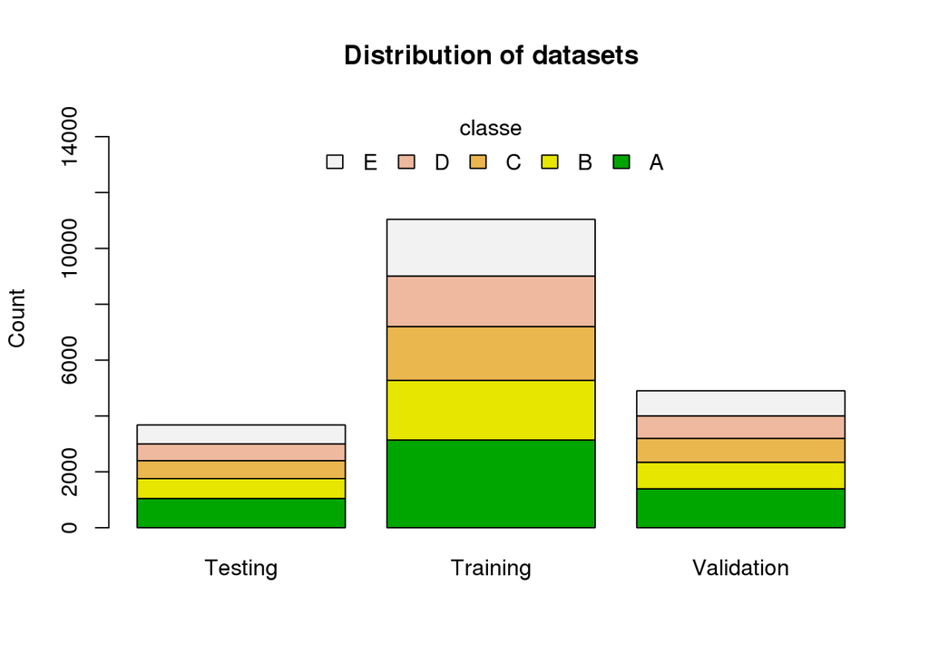

```r
setSplit = data.frame(classe=data$classe, set=0)
setSplit$set[-inWorking] = 'Validation'
setSplit$set[inWorking][inTrain] = 'Training'
setSplit$set[inWorking][-inTrain] = 'Testing'

setSplitTbl = table(setSplit)
barplot(setSplitTbl, legend = rownames(setSplitTbl),
        col=terrain.colors(length(unique(setSplit$classe))),
        main='Distribution of datasets', ylab='Count',
        args.legend = list(x="top", horiz = TRUE, box.lwd=NA, title='classe'),
        ylim=c(0,15000),
)
```

# Prediction

I use 3 different models with default parameters: Random Forest, Stochastic Gradient Boosting and Linear Discriminant Analysis.

```r
#Random Forest
#modFitRF=train(classe~., method='rf', data=training)
#save(modFitRF, file="modFitRF") #Its always a good idea to save computed model for later use.
load("modFitRF")

#Stochastic Gradient Boosting
#modFitGBM=train(classe~., method='gbm', data=training)
#save(modFitGBM, file="modFitGBM")
load("modFitGBM")

#Linear Discriminant Analysis
#modFitLDA=train(classe~., method='lda', data=training)
#save(modFitLDA, file="modFitLDA")
load("modFitLDA")

#Classe prediction with 3 different models
predRF = predict(modFitRF, testing)
predGBM = predict(modFitGBM, testing)
predLDA = predict(modFitLDA, testing)
```

### Accuracy of prediction with different models

```r
#Acccuracy calculation on testing set
cmRF = confusionMatrix(testing$classe,predRF)
cmGBM = confusionMatrix(testing$classe,predGBM)
cmLDA = confusionMatrix(testing$classe,predLDA)

printf('Accuracy of Random Forest model: %.5f', cmRF$overall["Accuracy"])
```

```
## [1] "Accuracy of Random Forest model: 0.99429"
```

```r
printf('Accuracy of Stochastic Gradient Boosting model: %.5f', cmGBM$overall["Accuracy"])
```

```
## [1] "Accuracy of Stochastic Gradient Boosting model: 0.96275"
```

```r
printf('Accuracy of Linear Discriminant Analysis model: %.5f', cmLDA$overall["Accuracy"])
```

```
## [1] "Accuracy of Linear Discriminant Analysis model: 0.73437"
```

# Combined model

I combine chosen models, hoping that it will give more accurate results.

```r
#Combine predictors
predDF = data.frame(predRF,predGBM,predLDA,classe=testing$classe)
#combModFit = train(classe ~.,method="rf",data=predDF)
#save(combModFit, file="combModFit")
load("combModFit")

combPred = predict(combModFit,predDF)
cmCombPred = confusionMatrix(testing$classe ,combPred)

printf('Accuracy of combined model: %.5f', cmCombPred$overall["Accuracy"])
```

```
## [1] "Accuracy of combined model: 0.99293"
```

Accuracy of combined model is lower than that of Random Forest, therefore I choose Random Forest to be my final model.

# Out of sample error

Here I check accuracy of my model on *validation* set.

```r
#out of sample error
predRFV = predict(modFitRF,validation)
cmRFV=confusionMatrix(predRFV, validation$classe)
printf('Out of sample accuracy: %.5f', cmRFV$overall["Accuracy"])
```

```
## [1] "Out of sample accuracy: 0.99592"
```

And finnaly I check out of sample accuracy of other models.

```r
predGBMV = predict(modFitGBM,validation)
predLDAV = predict(modFitLDA,validation)

predVDF <- data.frame(predRF=predRFV,predGBM=predGBMV, predLDA=predLDAV)
combPredV <- predict(combModFit,predVDF)

cmGBMV=confusionMatrix(predGBMV, validation$classe)
cmLDAV=confusionMatrix(predLDAV, validation$classe)
cmCombPredV=confusionMatrix(combPredV, validation$classe)

printf('Out of sample accuracy of Stochastic Gradient Boosting model: %.5f', cmGBMV$overall["Accuracy"])
```

```
## [1] "Out of sample accuracy of Stochastic Gradient Boosting model: 0.97186"
```

```r
printf('Out of sample accuracy of Linear Discriminant Analysis model: %.5f', cmLDAV$overall["Accuracy"])
```

```
## [1] "Out of sample accuracy of Linear Discriminant Analysis model: 0.73124"
```

```r
printf('Out of sample accuracy of combined model: %.5f', cmCombPredV$overall["Accuracy"])
```

```
## [1] "Out of sample accuracy of combined model: 0.99551"
```

Aparentely Random Forest model was a good choise, because on *validation* set it is more acurate comparing to other models, including combined model.

# Prediction of classe on 20 test cases

```r
testData=read.table("pml-testing.csv",header=T,sep=",") #load test data
testData=rename(testData, c("problem_id"="classe")) #
testData=testData[,vars] #select relevant predictors

predTEST = predict(modFitRF, testData)
answers = data.frame(problem_id=testData$classe, answer=predTEST)
answers
```

```
##    problem_id answer
## 1           1      B
## 2           2      A
## 3           3      B
## 4           4      A
## 5           5      A
## 6           6      E
## 7           7      D
## 8           8      B
## 9           9      A
## 10         10      A
## 11         11      B
## 12         12      C
## 13         13      B
## 14         14      A
## 15         15      E
## 16         16      E
## 17         17      A
## 18         18      B
## 19         19      B
## 20         20      B
```